# Tema 08 - Métodos basados en árboles

Árboles de Regresión y Clasificación. ‘Random Forest’

Pedro Albarrán

Dpto. de Fundamentos del Análisis Económico. Universidad de Alicante

Alberto Pérez

## Estratificación para asociaciones no lineales

- Ejemplo: relación no lineal entre las ventas y la edad
- Cuantos más particiones, mejor ajuste.
- PERO ¿dónde dividimos?, ¿cuántas particiones?

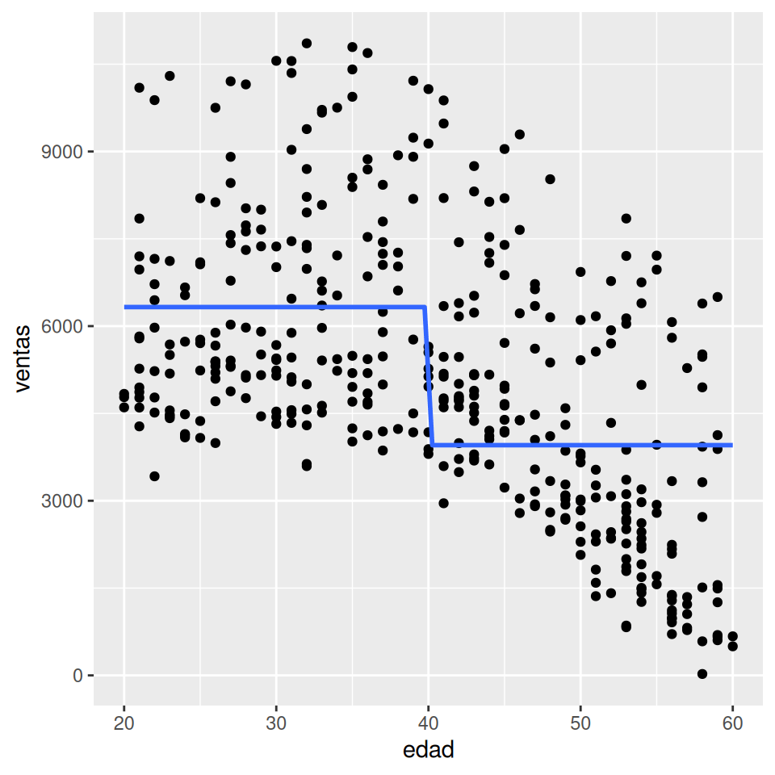

- Esta cuestión también aplica a las interacciones entre variables para capturar heterogeneidad del efecto de una variable: ¿cuántas interacciones? ¿con cuántos intervalos?

## Árboles de decisión

- Un árbol de decisión es un diagrama de flujo con reglas para segmentar el espacio de regresores en regiones más simples y clasificar observaciones

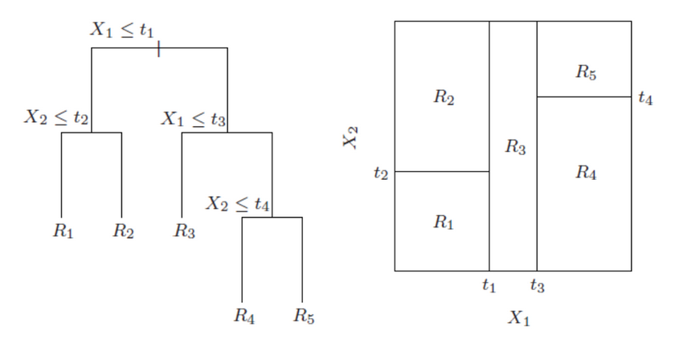

## Árboles de Regresión

- ¿Cómo construimos estos árboles para una variable cuantitativa?
  1. Dividir el espacio de predicción, $\small x_1, x_2, \dots, x_p$ en regiones $\small J$ distintas y no superpuestas, $\small R_1, R_2, \dots, R_J$
     - cada vez más homogéneas o “puras”: como todos los modelos, mismas características, mismo valor esperado de $y$
  2. Cada observación que caiga en la región $\small R_j$ tiene el mismo valor predicho: la media de $\small y$ para las observaciones de entrenamiento en $\small R_j$, $\small \widehat{y}_{i\in R_j}= \bar{y}_{R_j}$
- Es INVIABLE considerar todas las particiones en $\small J$ regiones
- Alternativas heurísticas: un algoritmo “voraz” elige una opción localmente óptima en cada paso con la esperanza de llegar a una solución general óptima
  - (en lugar de elegir la mejor partición para un paso futuro)

## Partición binaria recursiva

1. En la parte alta, todas las observaciones pertenecen a una sola región
2. Se divide sucesivamente cada región en dos ramas: $\small R_1(j,s) = \{X|X_j < s\}$ y $\small R_2(j,s) = \{X|X_j \geq s\}$
   - En cada nodo, se consideran *todos* los regresores $\small X_j$ y *todos* los umbrales $s$
   - Se calcula el error de predicción por particionar de esa manera $\small SCR_{j,s} = \sum_{i\in R_1(j,s)}(y_i-\widehat{y}_{R_1})^2 + \sum_{i\in R_2(j,s)}(y_i-\widehat{y}_{R_2})^2$
   - SOLO una partición en cada iteración: se elige $\small j$ y $\small s$ con menor $\small SCR_{j,s}$
3. Repetimos el proceso particionando cada región de la iteración anterior
4. Se continua hasta que se cumpla un criterio de parada; p.e., ninguna región contiene más de $5$ observaciones

## Podar un árbol (*pruning*)

- Evitar árboles demasiados complejos (“overfitting”)
- Hacer crecer un árbol “grande” con $\small T_0$ nodos terminales y **podarlo** para quedarnos con un sub-árbol con $\small T$ nodos terminales
  $$\small
  min \sum_{m=1}^T \sum_{i \in R_m} (y_i-\widehat{y}_{R_m})^2 + \alpha |T|$$
  donde $\small R_m$ es la región de $\small m$-nodo terminal
- $\small \alpha$ es el hiperparámetro de **coste de complejidad** de la poda, elegido por validación cruzada
- Disyuntiva entre más o menos nodos finales: mejor ajuste (menor SCR) frente a mayor penalización por complejidad

## Algoritmos para árboles e hiperparámetros

- Motores para árboles: `rpart` (defecto), `spark` y `C5.0` (solo clasificación)
- Depende de varios hiperparámetros elegidos por *tuning*
  - `min_n`: mínimo número de observaciones en un nodo parar dividirse más
  - `tree_depth`: máx. número de niveles de profundidad del árbol (no `C5.0`)
  - `cost_complexity`: coste de complejidad (sólo `rpart`)

```r
modelo_arbol  <- decision_tree(mode = "classification",
                               engine = "rpart",
                               cost_complexity = .01)
```

- Podemos visualizar un modelo árbol estimado con la biblioteca `rpart.plot`

```r
library(rpart.plot)
arbol <- flujo_arbol_est |> extract_fit_parsnip()
rpart.plot(arbol$fit)
```

[output not shown]

## Comentarios

- Predicción: media o clase mayoritaria de las observaciones de entrenamiento en el nodo terminal que corresponde a una observación nueva
- **Importancia** de las variables: la [biblioteca `vip`](https://koalaverse.github.io/vip/index.html) proporciona métricas sobre la influencia de cada predictor en las predicciones del modelo
  - algunas son específicas de un modelo: en árboles, la reducción total de la SCR o Gini debida a las particiones que usan una variable
  - otras generales: basadas en permutaciones, o en medidas de *Shapley*
- Ventajas de los árboles de decisión:
  - ajusta (no paramétricamente) relaciones no lineales/complejas
  - no requieren dummies ni transformaciones no lineales
  - fáciles de explicar y visualizar
- Desventajas: *overfit* (no robustos a cambios en los datos) y bajo poder de predicción

## *Bagging*

- Agregación de Bootstrap (*bagging*): procedimiento general para reducir la varianza, promediando $\small \{x_i\}_{i=1}^n iid \sim (\mu, \sigma^2) \Rightarrow \bar{x} \sim (\mu, \sigma^2/n)$
- Podemos tomar $B$ re-muestras del **único** conjunto de entrenamiento
- En lugar de un único árbol complejo, se combinan muchos árboles diversos que pueden reflejar patrones sutiles
- La variación muestral en las condiciones de “entrenamiento” se genera mediante “bootstrap”

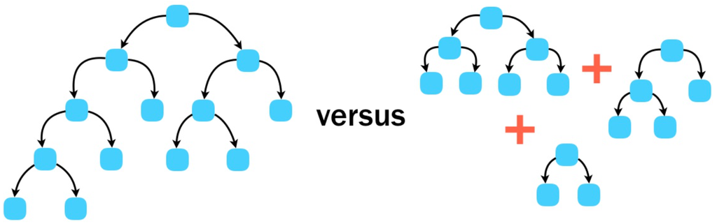

## “Random forest”

- Es un algoritmo específico de agregación de árboles que introduce aleatorización para **eliminar correlación** entre los árboles.
  - Se construyen varios árboles en muestras de entrenamiento de bootstrap
  - En cada partición de un árbol, se seleccionan aleatoriamente $\small m \approx \sqrt{k}\quad$ regresores del total
  - Se mitiga la influencia de regresores fuertes, permitiendo una mayor diversidad en los árboles agregados
- Mejor predicción a costa de la interpretación $\Longrightarrow$ métodos de interpretabilidad ex-post para aprendizaje automático: importancia, *Shapley values*, partial dependence plots (PDP)
  - La importancia se puede calcular como una media en los distintos árboles.
- De manera similar a los p-valores o LASSO, la importacia destaca qué variables considerar en modelos más interpretables, como regresión o árboles

## Algoritmos para RF e hiperparámetros

- Motores principales para RF en R: `ranger`, `randomForest` y `spark`
- Depende de `trees`, números de árboles, a considerar en la agregación (no genera “overfitting”) y de dos hiperparámetros
  - `mtry`: número de variables a considerar en cada partición
  - `min_n`: igual que en árboles

```r
library(ranger)
modelo_RF  <- rand_forest(mode = "regression", trees = 100,
                          mtry = 3, min_n = 5) |>
              set_engine("ranger", importance = "permutation")
              # importance = "impurity" en clasificación

RF <- flujo_RF_est |> extract_fit_parsnip()
library(vip)
RF |> vi()
RF |> vip()
```

[output not shown]